# C3 - A Minimal Theory of Linear Models

2020-10-01

## Learning Outcomes

- Assumptions of the linear model.
- Least square estimation.
- Sampling distribution of least square estimator.

## Recap

- The general idea: find a (best possible) line to summarise the relationship between two variables.
- How can we do this job in R by `lm()`?
- What is the results of `lm()` and how can we access them by `summary()` and `coef()`?
- Overlay a fitted line with the scatter plot by `geom_abline()`.

## Focus

- When can we use linear regression? Sometimes, it is not clever to use a linear model, say predicting the numbers of confirmed cases of covid-19 in NZ.
- What do we mean by a best possible **LINE**? Two points will determine a line! So three, four, or even more?
- How can we find the best intercept and the slope? Calculate manually or leave it to R by `lm()`?

## The Gauss-Markov Assumptions

## Assumptions of linear models

**L**inearity

- Residuals don’t depend on \(x\). The trend is correctly modelled.

**I**ndependence

- Residuals don’t depend on each other.

**N**ormality

- Residuals are distributed normally.

**E**qual variance

- Residuals have constant variance. The variation doesn’t change as we move along the trend.

## A Math Formualtion of Linear Model

\[ y=\alpha+\beta x +\varepsilon \]

- Response: \(y\)
- Covariate: \(x\)
- Regression Coefficients (Parameters): \(\alpha\) and \(\beta\)
- Random Error (Residual): \(\varepsilon\)

## A Math Formualtion of Linear Model

- Say, we have observed multiple pairs of \(y\) and \(x\) as \((x_1,y_1),(x_2,y_2),\ldots,(x_n,y_n)\).

\[ y_1=\alpha+\beta x_1 +\varepsilon_1, \] \[ y_2=\alpha+\beta x_2 +\varepsilon_2, \] \[ \vdots \] \[ y_n=\alpha+\beta x_n +\varepsilon_n, \]

## Gauss-Markov Assumptions

- Given a linear model \(y_i=\alpha+\beta x_i +\varepsilon_i,i=1,\ldots,n\), all four assumptions can be summarised in the following expression:

\[ \varepsilon_i \mathop{\sim}\limits_\mathsf{iid} \mathsf{Normal}(0, \sigma^2) \]

- \(\mathsf{mean}[\varepsilon_i]=0\) ensures the **L**inearity.
- \(\mathsf{iid}\)(*identically and independently distributed*) ensures the **I**ndependence.
- \(\mathop{\sim}\mathsf{Normal}\) ensures the **N**ormality.
- \(Var(\varepsilon_i)=\sigma^2\) ensures the **E**qual variance
- The four assumptions are called **the Guass-Markov assumptions**

## Wny do we need assumptions?

- These four assumptions are critical for deriving the theory of linear model.
- Assumptions hold forever in the theory. No need to worry about the theory.
- They are even more critical to our practices! Without the warranty of Gauss and Markov, the statistical inference of linear model can easily be non-sense.
- However, assumptions may not hold for most practical problems.
- The next lecture C4 **Residual Diagnostics** will investigate this topic.

## Least Sqaure Estimation

## Minimising the residuals

- Supposing that the Gauss-Markov assumptions are all satisfied, we will estimate the regression coefficients now, i.e. guessing the values of \(\alpha\) and \(\beta\) in an educated manner.
- Denote a pair of arbitrary guesses by \(\tilde{\alpha}\) and \(\tilde{\beta}\). Unless we receive an oracle, it won’t equal to the ground truth denoted by \(\alpha\) and \(\beta\).
- For each point \(x_i\) we have the corresponding estimated value \(\tilde{y}_i = \tilde\alpha + \tilde\beta x_i\).
- The difference between the real \(y_i\) and fitted \(\tilde{y}_i\) is the **residual** \(\tilde\varepsilon_i = y_i - \tilde{y}_i\).
- A good combination of \(\tilde{\alpha}\) and \(\tilde{\beta}\) gets all residuals (or most residuals) closer to zero.

## Minimising the variance of residuals

- If we have only two pairs of observations, we can easily draw a line between them with residuals zero.
- Given more then two points, what can we do ?
- We need some tools to measure the overall performance of a fitted line in terms of residuals.
- One way is to minimise the variance of the residuals, subject to their mean being 0. (Why mean 0?)

## Least squares estimation

- This is called **least squares** estimation as the formula for variance contains a sum of squares \[ \begin{aligned} \mathsf{var}(\tilde\varepsilon_i) &= \frac{1}{n}\sum_{i=1}^n (\tilde\varepsilon_i - 0)^2= \frac{1}{n}\sum_{i=1}^n [y_i - (\tilde\alpha + \tilde\beta x_i)]^2 \end{aligned} \]
- By minimising the **residual variance** \(\mathsf{Var}_\mathsf{res} = \frac{1}{n}\sum_{i=1}^n [y_i - (\hat\alpha + \hat\beta x_i)]^2\), we obtain the corresponding values of \(\tilde\alpha\) and \(\tilde\beta\) which are called **least squares estimates**.
- We often put hats on parameters (\(\hat{\alpha}\), \(\hat{\beta}\)) to denote the least square estimates. This helps us remember that they’re sample statistics and differentiate them from the true values \(\alpha\) and \(\beta\) from the population and the arbitrary guesses \(\tilde\alpha\) and \(\tilde\beta\).

## A Toy Example

- Let’s consider a even simpler model - \(\mathsf{mean}[y]=\beta x\). The intercept \(\alpha\) is set as zero. We only need to estimate \(\beta\).
- We observed two pairs of observations \((x_1,y_1)=(4,5)\) and \((x_2,y_2)=(6,3)\). Then,

\[\mathsf{Var}_\mathsf{res}(\tilde\beta)=[(y_1-\tilde\beta x_1)^2+(y_2-\tilde\beta x_2)^2]/2\]

- After some simplifications, we have \[\mathsf{Var}_\mathsf{res}(\tilde\beta)=a\tilde\beta^2+b\tilde\beta+c\] where \(a=(x_1^2+x_2^2)/2=26,b=-(x_1y_1+x_2y_2)=-38,c=(y_1^2+y_2^2)/2=17\).

## A Toy Example

- Clearly, \(\mathsf{Var}_\mathsf{res}(\tilde\beta)=26\tilde\beta^2-38\tilde\beta+17\) is a quadratic function of \(\tilde\beta\). We can plot it in R as follows

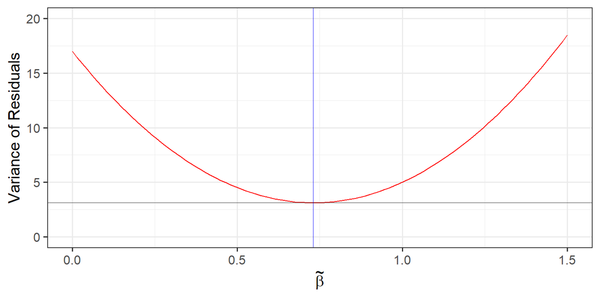

## A Toy Example

- Some calculus operations will reveal that \(\mathsf{Var}_\mathsf{res}\) attains its minimum at \(\tilde\beta=19/26\approx0.7308\).
- We can of course leave all the calculations to R.

```r
x <- c(4,6)
y <- c(5,3)
no_intercept  <- lm(y~x-1)
```

- To fit a linear model without intercept, we add `-1` to the right hand side of the formula `y~x`.

## A Toy Example

```r
summary(no_intercept)
```

```
Call:
lm(formula = y ~ x - 1)

Residuals:
     1      2
 2.077 -1.385

Coefficients:
  Estimate Std. Error t value Pr(>|t|)
x   0.7308     0.3462   2.111    0.282

Residual standard error: 2.496 on 1 degrees of freedom
Multiple R-squared:  0.8167,    Adjusted R-squared:  0.6335
F-statistic: 4.457 on 1 and 1 DF,  p-value: 0.2816
```

## Try some hard examples

- Given three or more pairs of observations, we can still estimate \(\beta\) manually or by R.
- **Task**: Add a new observation \((x_3,y_3)=(9,12)\) to the two observations in our toy example. Re-estimate \(\beta\) with all three observations with R.
- One can further estimate both the slope and the intercept in a linear model provided that the intercept is non-zero. To estimate two parameters simultaneously, i.e. \(\alpha\) and \(\beta\), we will need some knowledge on **Multivariate Calculus**.
- The procedure of finding the minimum(or maximum) of a function is called **optimisation**. **Optimisation** is largely a math concept, but it plays a very important role in modern statistics!
- Let’s forget these math details. R can do all these jobs for us (quickly and nicely)!

## Estimator and Estimate

- Go back to our toy example. This time we will use the abstract symbols \((x_1,y_1)\) and \((x_2,y_2)\).
- We can work out the residual variance as

\[\mathsf{Var}_\mathsf{res}(\tilde\beta)=[(x_1^2+x_2^2)\tilde\beta^2-2(x_1y_1+x_2y_2)\tilde\beta+(y_1^2+y_2^2)]/2\]

- The minimum of residual variance is attained at the least squares estimate \[\hat\beta=\frac{x_1y_1+x_2y_2}{x_1^2+x_2^2}\]
- This generic form of \(\hat\beta\) is called the least square **estimator**.
- If we substitute the numerical values of observed data into the estimator, we obtain some numbers like \(\hat\beta=19/26\approx0.7308\) which is called an **estimate**.

## Estimator and Estimate

- An **estimate** is calculated from the real data but an **estimator** is calculated (derived) from the abstract data.
- If you know the math form of the least squares **estimator**, you can easily obtain the least squares **estimates** for arbitrary samples.
- The summary of `lm()` provides us the least square estimates, rather than estimators. Actually the least square estimators have been integrated into `lm()`. So we can run `lm()` on any data set.
- Statisticians devote a huge efforts in finding good estimators and programming them into R packages!

## Estimator as a random variable

- Recall that \(y_1=\beta x_1+\varepsilon_1\) and \(y_2=\beta x_2+\varepsilon_2\), we can substitute them into our toy least square estimator \(\hat\beta=\frac{x_1y_1+x_2y_2}{x_1^2+x_2^2}\) which yields \[\hat\beta=\frac{x_1(\beta x_1+\varepsilon_1)+x_2(\beta x_2+\varepsilon_2)}{x_1^2+x_2^2}=\beta+\frac{x_1\varepsilon_1+x_2\varepsilon_2}{x_1^2+x_2^2}\]
- \(\hat\beta\) can be regarded as the sum of the ground truth \(\beta\) and the random disturbance \(\frac{x_1\varepsilon_1+x_2\varepsilon_2}{x_1^2+x_2^2}\).
- \(\hat\beta\) is also random! The source of the randomness is \(\varepsilon_1\) and \(\varepsilon_2\). We can study the distribution of \(\hat\beta\) to get a general idea of its behavior given arbitrary samples.
- Some math operations will reveal that \(\mathsf{mean}[\hat\beta]=\beta\)!

## Hints on the mean of random variables

\[ \begin{aligned} \mathsf{mean}[X+Y]&=\mathsf{mean}[X]+\mathsf{mean}[Y]\\ \mathsf{mean}[X+Y+Z]&=\mathsf{mean}[X]+\mathsf{mean}[Y]+\mathsf{mean}[Z]\\ \mathsf{mean}[aX]&=a\cdot\mathsf{mean}[X]\\ \mathsf{mean}[aX+b]&=a\cdot\mathsf{mean}[X]+b\\ \mathsf{mean}[aX+bY]&=???\\ \mathsf{mean}\left[\sum_{i=1}^nX_i\right]&=???\\ \mathsf{mean}\left[\sum_{i=1}^na_iX_i\right]&=??? \end{aligned} \]

## Hints on the mean of random variables

\[ \begin{aligned} \mathsf{mean}[X+Y]&=\mathsf{mean}[X]+\mathsf{mean}[Y]\\ \mathsf{mean}[X+Y+Z]&=\mathsf{mean}[X]+\mathsf{mean}[Y]+\mathsf{mean}[Z]\\ \mathsf{mean}[aX]&=a\cdot\mathsf{mean}[X]\\ \mathsf{mean}[aX+b]&=a\cdot\mathsf{mean}[X]+b\\ \mathsf{mean}[aX+bY]&=a\cdot\mathsf{mean}[X]+b\cdot\mathsf{mean}[Y]\\ \mathsf{mean}\left[\sum_{i=1}^nX_i\right]&=\sum_{i=1}^n\mathsf{mean}[X_i]\\ \mathsf{mean}\left[\sum_{i=1}^na_iX_i\right]&=\sum_{i=1}^na_i\cdot\mathsf{mean}[X_i] \end{aligned} \]

## Sampling distribution of our estimators

- As long as the Guass-Markov assumptions hold then \(\hat\alpha\) and \(\hat\beta\) both have normal distributions.
- We won’t bother with the equations for them, other than to note:
  - The estimates \(\hat\alpha\) and \(\hat\beta\) are **unbiased**, i.e. \[ \mathsf{mean}[\hat\alpha]= \alpha, \qquad \mathsf{mean}[\hat\beta] = \beta \]
  - The standard errors of \(\hat\alpha\) and \(\hat\beta\) decrease with \(n\) in the same way that the standard error of the sample mean decreases with \(n\).
  - We can test hypotheses about \(\alpha\) and \(\beta\) using these distributions.

## Plot a simple function in R

## Function in R

- To plot a function, must learn to write functions in R.
- We write a simple function to evaluate the residual variance in the toy example \(\mathsf{Var}_\mathsf{res}(\tilde\beta)=26\tilde\beta^2-38\tilde\beta+17\).

  ```r
  Var_res <- function(beta_tilde) 26*beta_tilde^2-38*beta_tilde+17
  Var_res(2)
  ```

  ```
  [1] 45
  ```

- `Var_res()` is a user-defined function, i.e. our own R functions.
- It will be sufficient for us to write some simple R functions as statistician has written most complicated R functions for us!

## Plot a function in R

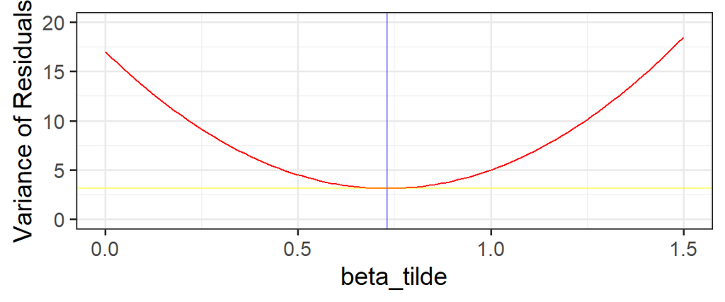

```r
library(ggplot2)
Var_res <- function(beta_tilde) 26*beta_tilde^2-38*beta_tilde+17
ggplot() + xlim(0, 1.5) + ylim(0,20) +
  geom_function(fun = Var_res, col='red') +
  geom_vline(xintercept = 19/26, col='blue', alpha=0.5) +
  geom_hline(yintercept = Var_res(19/26), col='yellow', alpha=0.5) +
  xlab("beta_tilde") + ylab("Variance of Residuals")
```

## Hint on making the plot

- The key is `geom_function()`. But before calling it, you should create your ggplot object by `ggplot()` and specify the range of \(x\) by `xlim()`.
- In `geom_function()`, specify the function to be plotted in the argument `fun`. You can try some different functions, e.g. `exp`, `dnorm` and `pnorm`.
- We add the vertical line and horizontal line corresponding to the minimum of the residual variance by `geom_vline()` and `geom_vline()` by specifying the argument `xintercept` and `yintercept`. This can also be done by `geom_abline()` with the same arguments.
- Try different values in `xlim()` and `ylim()` and adjust `alpha` and `color` for better visualization effects.

## Summary

- Assumptions for linear model
- Least squares estimation
- Estimator, estimate, and sampling distribution
- Create your own functions and make its plot